# Satellite

## HOOT Workshop #1: GOES-19 Satellite Imagery

#### February 24, 2025

In this workshop, we will plot satellite imagery from GOES-19, the latest and final satellite in the GOES-R Series that was launched last summer. While currently non-operational, it is scheduled to replace GOES-16 as GOES-East this spring!

Before we begin, you'll need to install the following packages:

- **fsspec**
- **s3fs**
- **h5netcdf**
- **xarray**
- **numpy**
  - Data manipulation
- **metpy**
  - For specific color tables
- **cartopy**
  - Mapping / projections
- **matplotlib**
  - Plotting / visualizations

We will use fsspc, s3fs, and h5netcdf to extract and read GOES-R Series data stored as **netCDF** files via Amazon Web Service (AWS)'s cloud storage service (S3). After reading in the data, we will convert the netCDF file into a more usable **Dataset** format via xarray before plotting.

```python
pip install fsspec
```

```python
pip install s3fs
```

```python
pip install h5netcdf
```

Once we have those packages installed, we'll need to import them.

```python
import fsspec
import s3fs
import xarray as xr
import numpy as np
from datetime import datetime
import matplotlib.pyplot as plt
import cartopy.crs as ccrs

from metpy.plots import ctables
```

#### Map domain

First, we'll specify some information about the extent of our map's domain; the satellite, product, and channel we'll be using; and the date and time of our satellite imagery, which we store as variables for later use.

Initially, our satellite imagery will be stored in geostationary projection. After converting to a more useful projection (Plate Carree), we'll zoom in and center our map on a specific latitude/longitude coordinate (in this case, we'll center our map on Norman).

#### Satellite type

We also need to specify which satellite to use. While we'll use GOES-19 here, AWS also stores data from GOES-16, GOES-17, and GOES-18 since 2019. GOES-16 is the operational GOES-East while GOES-18 is the operational GOES-West, which replaced GOES-17. For more information about the satellite data stored in AWS, see: https://registry.opendata.aws/noaa-goes/

#### Satellite instruments

GOES-R Series satellites contain several instruments and many different products. We will use Level 2 (L2) Advanced Baseline Imager (ABI) data, which contains 16 different spectral bands, or channels, that observe radiation at various wavelengths. This data is also provided for three different geographic domains:

- **Full Disk** (entire Western Hemisphere)
- **CONUS** (continental US)
- **Mesoscale** (1,000 km x 1,000 km)
  - Movable rectangular regions based on current weather
  - [Mesoscale Mission Viewer](https://vlab.noaa.gov/web/towr-s/mmm/meso-view): View current and archived mesoscale domain locations

Specifically, we will use **ABI-L2-MCMIPC**, or Advanced Baseline Imager Level 2 Cloud and Moisture Imagery CONUS.

For a full list of available GOES-R Series products in the database, see https://github.com/NOAA-Big-Data-Program/nodd-data-docs/tree/main/GOES.

```python
## CONFIG ##
# Map bounds
lat_center = 35 # Central latitude (degrees)
lon_center = -97 # Central longitude (degrees)
extent = 10 # Map extent from central coordinates (degrees)

# Satellite info
goes_type = '19' # Specify which GOES-R satellite to use (options: 16, 17, 18, or 19)
product_name = 'ABI-L2-MCMIPC' # Name of the product we'll use
band = '2' # Spectral band / channel

# Datetime info
year = 2025
day = 55 # Month is not specified, so this is the day in terms of the entire year
hour = 21
```

#### GOES Bands

Of the 16 spectral bands available in ABI, four of the most important to us are:

- **Visible Red** (Band 2: $0.64\ \mu m$)
- **IR Shortwave** (Band 7: $3.9\ \mu m$)
- **IR Mid-Level Tropospheric Water Vapor** (Band 9: $6.9\ \mu m$)
- **IR Longwave** (Band 14: $11.2\ \mu m$)

Below, we specify key information about each band:

- Wavelength (in $\mu m$)
- Description (i.e. Visible Red)
- Lower limit (lowest expected value)
- Upper limit (highest expected value)
- Gamma (used to determine image brightness)
  - $V_{out} = V_{in}^{1/\gamma}$
- Colormap (color scale)
- Normalization
  - Makes sure the colormap used fully covers the range of values available
  - Only needed for the IR longwave and water vapor channels

For visible bands, which measure reflectance, the lower and upper bounds are (0, 1). However, infrared (IR) bands, which measures brightness temperature (K), can be a bit more loose and subjective.

For a full list of ABI bands and their specifications, see:

- https://www.goes-r.gov/spacesegment/ABI-tech-summary.html
- https://www.goes-r.gov/mission/ABI-bands-quick-info.html

```python
## ABI Bands ##
# Visible (Day)
if band=='2':
    wavelength='0.64'
    description='Visible Red'
    lower_lim=0
    upper_lim=1
    gamma=2
    norm = None
    cmap='gray'

# Infrared (Night)
elif band=='7':
    wavelength='3.9'
    description='IR Shortwave'
    lower_lim=273.15-80 # Brightness temperature expressed as a deviation from 0C
    upper_lim=273.15+50
    gamma=1
    norm = None
    cmap='gray_r'

# Longwave
elif band=='9':
    wavelength='6.9'
    description='IR Mid-Level Tropospheric Water Vapor'
    lower_lim=273.15-109
    upper_lim=273.15+20
    gamma=1
    norm, cmap = ctables.registry.get_with_range('WVCIMSS_r', lower_lim, upper_lim) # Use special water vapor colormap from metpy

# Longwave
elif band=='14':
    wavelength='11.2'
    description='IR Longwave'
    lower_lim=273.15-110
    upper_lim=273.15+26
    gamma=1
    norm, cmap = ctables.registry.get_with_range("ir_tpc_r", lower_lim, upper_lim) # Use special IR colormap from metpy

# Map extent
N = lat_center + extent # Northern boundary
S = lat_center - extent # Southern boundary
E = lon_center + extent # Eastern boundary
W = lon_center - extent # Western boundary

print(f'GOES-{goes_type} ABI Channel {band}: {wavelength} μm ({description})\n')
```

```
GOES-19 ABI Channel 2: 0.64 μm (Visible Red)
```

### Data Access

Now that we've defined the specifications of our data, we can now extract it.

We will need to read in the files stored in AWS's cloud storage servers. The netCDF (.nc) files it contains are stored in hourly folders according to the following format:

- Product/Year/Day of Year/Hour/Filename

For instance, our files will look something like this:

- s3://noaa-goes19/ABI-L2-MCMIPC/2025/55/22/OR_*.nc

We represent this as a *formatted string* using the variables we've already assigned:

- f"s3://noaa-goes{goes_type}/{product_name}/{year}/{day:03.0f}/{hour:02.0f}/OR_{product_name}*.nc"

We need to extract all of the files listed in the hour we specified. To do this, we create a list using brackets []. We fill this list with all of the files in our desired hour using the .glob() function. The asterisk * is used to specify that we want every file whose name starts with everything before it

- In our case, they must all start with s3://noaa-goes19/ABI-L2-MCMIPC/2025/55/22/OR_ABI-L2-MCMIPC

```python
# Access files stored in AWS S3 database
fs = fsspec.filesystem('s3', anon=True)

# List containing the name of GOES NetCDF files for our specified hour
urls = ['s3://' + f
        for f in fs.glob(
            f"s3://noaa-goes{goes_type}/{product_name}/{year}/{day:03.0f}/{hour:02.0f}/OR_{product_name}*.nc"
        )]

# Print all the files in our hour
print("AWS S3 Files: ", urls)
```

```
AWS S3 Files:  ['s3://noaa-goes19/ABI-L2-MCMIPC/2025/055/21/OR_ABI-L2-MCMIPC-M6_G19_s20250552101173_e20250552103551_c20250552104077.nc', 's3://noaa-goes19/ABI-L2-MCMIPC/2025/055/21/OR_ABI-L2-MCMIPC-M6_G19_s20250552106173_e20250552108552_c20250552109067.nc', 's3://noaa-goes19/ABI-L2-MCMIPC/2025/055/2…
```

Woah, there's a lot of files! Let's break down the file name.

For instance, let's use 'OR_ABI-L2-MCMIPC-M6_G19_s20250552101173_e20250552103551_c20250552104077.nc'.

- **OR:** Operational
- **ABI:** Instrument type
- **L2:** Level 2 Data
- **MCMIP:** Multichannel Cloud and Moisture Imagery products
- **C:** CONUS file
- **M6:** Scan mode
- **G19:** GOES-19
- **s**20250552101173: Scan start (4 digit year, 3 digit day of year, hour, minute, second, tenth second)
- **e**20250552103551: Scan end
- **c**20250552104077: File Creation
- **.nc**: NetCDF file extension

### Data Extraction

Next, we will open the most recent file in that hour. To specify the last item in a list, we use -1 to index the list (i.e., urls[-1]). To choose the first file in a list (index of 0), we would specify urls[0].

While that file is open, we read it and convert from netCDF format to a Dataset (from xarray).

```python
# Open most recent file
with fs.open(urls[-1], mode="rb") as file_obj:
    # Convert NetCDF to xarray Dataset
    with xr.open_dataset(file_obj, engine='h5netcdf') as ds:
        ds = ds.load()

print("\nDS: ", ds)

# Close data streams (best practice for performance and resource management)
ds.close()
file_obj.close()
```

```
DS:  <xarray.Dataset> Size: 480MB
Dimensions:                                 (y: 1500, x: 2500,
                                             number_of_time_bounds: 2,
                                             number_of_image_bounds: 2, band: 1)
Coordinates: (12/37)
    t                                       datetime64[ns] 8B 2025-02-24T21:5...
  * y                                       (y) float32 6kB 0.1265 ... 0.04259
  * x                                       (x) float32 10kB -0.07501 ... 0.0...
    y_image                                 float32 4B 0.08456
    x_image                                 float32 4B -0.00504
    band_wavelength_C01                     (band) float32 4B 0.47
    ...                                      ...
    band_id_C11                             (band) int8 1B 11
    band_id_C12                             (band) int8 1B 12
    band_id_C13                             (band) int8 1B 13
    band_id_C14                             (band) int8 1B 14
    band_id_C15                             (band) int8 1B 15
    band_id_C16                             (band) int8 1B 16
Dimensions without coordinates: number_of_time_bounds, number_of_image_bounds,
                                band
Data variables: (12/124)
    CMI_C01                                 (y, x) float32 15MB 0.2514 ... 0....
    DQF_C01                                 (y, x) float32 15MB 0.0 0.0 ... 0.0
    CMI_C02                                 (y, x) float32 15MB 0.1813 ... 0....
    DQF_C02                                 (y, x) float32 15MB 0.0 0.0 ... 0.0
    CMI_C03                                 (y, x) float32 15MB 0.2038 ... 0....
    DQF_C03                                 (y, x) float32 15MB 0.0 0.0 ... 0.0
    ...                                      ...
    mean_brightness_temperature_C16         float32 4B 262.1
    std_dev_brightness_temperature_C16      float32 4B 16.28
    percent_uncorrectable_GRB_errors        float32 4B 0.0
    percent_uncorrectable_L0_errors         float32 4B 0.0
    dynamic_algorithm_input_data_container  int32 4B -2147483647
    algorithm_product_version_container     int32 4B -2147483647
Attributes: (12/29)
    naming_authority:          gov.nesdis.noaa
    Conventions:               CF-1.7
    Metadata_Conventions:      Unidata Dataset Discovery v1.0
    standard_name_vocabulary:  CF Standard Name Table (v35, 20 July 2016)
    institution:               DOC/NOAA/NESDIS > U.S. Department of Commerce,...
    project:                   GOES
    ...                        ...
    date_created:              2025-02-24T21:59:06.9Z
    time_coverage_start:       2025-02-24T21:56:17.3Z
    time_coverage_end:         2025-02-24T21:58:55.1Z
    timeline_id:               ABI Mode 6
    production_data_source:    Realtime
    id:                        f7ce87d3-54e1-45b9-a3d9-50b9980021ce
```

Printing the Dataset out, we see there's a lot of information about our GOES data. The file itself is also quite large (480 MB!).

After loading the Dataset, we close our connection to the file.

#### Scan Timing

In the 'Attributes' of our Dataset, we see that there's multiple different timestamps specified. We can access these attributes using ds.{attribute} (e.g., ds.time_coverage_start)

We can convert these timestamps from a string object to a formatted datetime object using the .strptime() function in datetime. We use % to specify the format (i.e. %Y for year, %m for month, etc.)

```python
scan_start = datetime.strptime(ds.time_coverage_start, "%Y-%m-%dT%H:%M:%S.%fZ") # Scan's start time, converted to datetime object
scan_end = datetime.strptime(ds.time_coverage_end, "%Y-%m-%dT%H:%M:%S.%fZ") # Scan's end time, converted to datetime object
file_created = datetime.strptime(ds.date_created, "%Y-%m-%dT%H:%M:%S.%fZ") # File creation time, convert to datetime object

midpoint = str(ds["t"].data)[:-8] # The 't' variable is the scan's midpoint time
scan_mid = datetime.strptime(midpoint, "%Y-%m-%dT%H:%M:%S.%f") # Convert midpoint time to a regular datetime object

print("\nScan Start    : %s" % scan_start)
print("Scan midpoint : %s" % scan_mid)
print("Scan End      : %s" % scan_end)
print("File Created  : %s" % file_created)
print("Scan Duration : %.2f minutes" % ((scan_end - scan_start).seconds / 60))
```

```
Scan Start    : 2025-02-24 21:56:17.300000
Scan midpoint : 2025-02-24 21:57:36.200000
Scan End      : 2025-02-24 21:58:55.100000
File Created  : 2025-02-24 21:59:06.900000
Scan Duration : 2.62 minutes
```

We can see that a single scan isn't completed at a precise timestamp, but rather over a range of time. In this case, the scan took about 2.62 minutes, although this number will vary depending on scan mode and domain.

### Load channel data

Next, we access the data for the specified band / channel that we want. To access a variable in the Dataset, we use ds[{variable}] (e.g. ds['CMI_C02'] to access Channel 2). Since we just want the variable's data (and not its specifications), we apply .data at the end.

We also apply the lower and upper numerical bounds to our data using the .clip() function from numpy, and apply the gamma correction to adjust the brightness of our image ($V_{out} = V_{in}^{1/\gamma}$).

```python
# Load the channel
channel = ds[f"CMI_C{float(band):02.0f}"].data
# Apply range limits for each channel.
channel = np.clip(channel, lower_lim, upper_lim)
# Apply a gamma correction to the image (brightness)
channel = np.power(channel, 1 / gamma)
```

### Plot Satellite Image

To plot our image, we first need to create a figure and Axes object from matplotlib. We can do this using the .subplots() function, which creates a grid of subplots.

plt.subplots(1, 1, figsize=(16, 12))

- (1,1) refers to (# columns, # rows) of the subplot grid
- figsize=(16,12) refers to (width, height)

Finally, we plot the image for our channel/band onto the Axes object using .imshow():

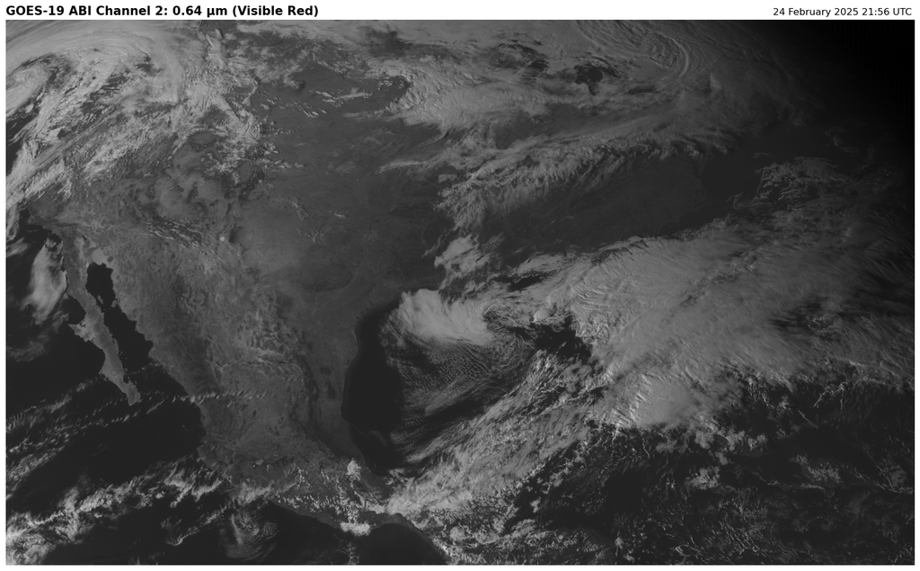

```python
# Make first plot (Geostationary projection)
fig, ax = plt.subplots(1, 1, figsize=(16, 12))
im = ax.imshow(channel, cmap=cmap, vmax=upper_lim, vmin=lower_lim)

# Only normalize the data to match the colormap if we're using certain bands whose colormaps need normalization
if norm is not None:
    im.set_norm(norm)

# Set title
plt.title(f'GOES-{goes_type} ABI Channel {band}: {wavelength} μm ({description})', fontweight="semibold", fontsize=15, loc="left")
plt.title("%s" % scan_start.strftime("%d %B %Y %H:%M UTC "), loc="right")

# Remove axis ticks and labels
ax.axis("off")

# Adjust padding around the plot
plt.tight_layout()

# Save the figure as a .png file to the current directory
plt.savefig(f'\nGOES-{goes_type} ABI Channel {band}: {wavelength} μm ({description}): {scan_start.strftime("%d %B %Y %H:%M UTC ")}.png')
```

### Georeference and Convert Map Projection

The imagery we plotted looks neat, but the satellite is pointing at an angle with the surface. Thankfully, we can georeference the imagery and convert it from its default geostationary projection to a projection that's easier to view.

To do this, we'll need some more metadata from the satellite:

- Satellite height
- Satellite longitude
- Major (zonal) axis
- Minor (meridional) axis
- Scanning angles for x, y coordinates (in radians)

With the scanning angles and satellite height, we can calculate the (x,y) coordinates for the satellite imagery in a geostationary projection.

```python
# Satellite constants
sat_h = ds["goes_imager_projection"].perspective_point_height # Satellite height
sat_lon = ds["goes_imager_projection"].longitude_of_projection_origin # Satellite longitude
semi_major = ds["goes_imager_projection"].semi_major_axis # Zonal axis
semi_minor = ds["goes_imager_projection"].semi_minor_axis # Meridional axis

# Get scanning angles (radians)
x_1d = ds["x"].data
y_1d = ds["y"].data

# Geostationary projection x and y coordinates (scanning angle * satellite height)
x = x_1d * sat_h
y = y_1d * sat_h
```

Now, let's georeference the geostationary projection and then convert to a different projection, **Plate Carree**, using cartopy.

```python
# Georeference and convert projection
globe = ccrs.Globe(semimajor_axis=semi_major, semiminor_axis=semi_minor) # Define the globe based on satellite's major and minor axes
geos_crs = ccrs.Geostationary(central_longitude=sat_lon, satellite_height=sat_h, globe=globe) # Georeference the geostationary projection
proj = ccrs.PlateCarree() # Plate Carree projection
```

Now we can plot the georeferenced figure and satellite imagery. We will also apply the map bounds that we defined at the start.

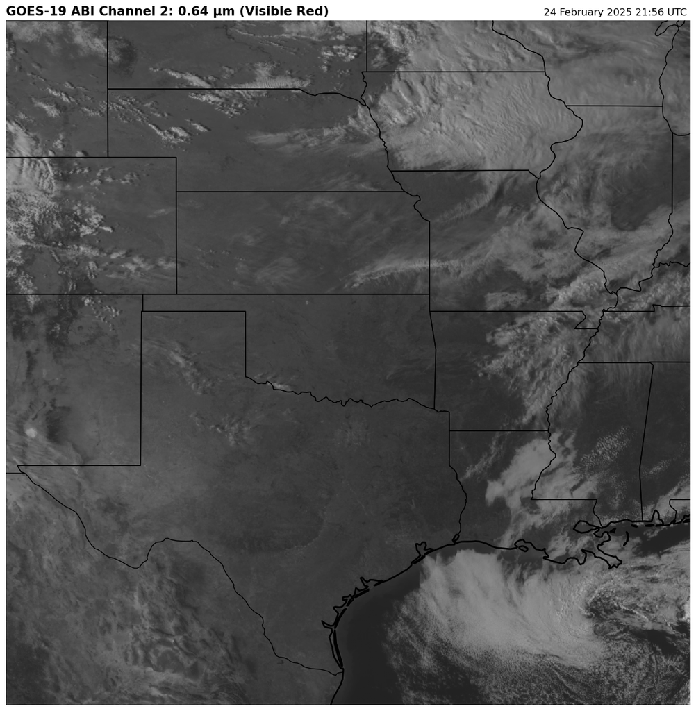

```python
# Define figure and Axes
fig = plt.figure(figsize=(15, 12))
ax = fig.add_subplot(1, 1, 1, projection=proj) # Specify that the subplot contains the new Plate Carree projection

ax.axis('off') # Invisible axis
ax.set_extent([W, E, S, N]) # Apply map bounds

# Plot image
im = ax.imshow(
        channel,
        origin="upper", # Flip image (otherwise it will be upside down)
        extent=(x.min(), x.max(), y.min(), y.max()), # Extent of satellite's domain
        transform=geos_crs, # Transform from geostationary projection (geos_crs)
        cmap = cmap, # Apply colormap
        interpolation=None,
        vmin = lower_lim, # Apply lower limit
        vmax = upper_lim # Apply upper limit
)

# Only apply normalization for speciifc bands
if norm is not None:
    im.set_norm(norm)

# Add a colorbar for infrared (IR) products
if 'IR' in description:
    cbar = plt.colorbar(im, ax=ax, extend="both", shrink=0.8, pad=0.02)
    cbar.set_label("Brightness Temperature (K)", fontsize=12, labelpad=10)  # Increase font size
    cbar.ax.tick_params(labelsize=10)  # Adjust tick font size

# Add map features
ax.coastlines(resolution="50m", color="black", linewidth=2)
ax.add_feature(ccrs.cartopy.feature.STATES)

# Set title
plt.title(f'GOES-{goes_type} ABI Channel {band}: {wavelength} μm ({description})', loc="left", fontweight="semibold", fontsize=15)
plt.title("%s" % scan_start.strftime("%d %B %Y %H:%M UTC "), loc="right")

# Adjust plot's padding
plt.tight_layout()

# Save figure as png
plt.savefig(f"GOES-{goes_type} ABI Channel {band}: {wavelength} μm ({description}): {scan_start.strftime("%d %B %Y %H:%M UTC ")}.png")
```

Sweet, now we have satellite imagery centered over central Oklahoma! Feel free to adjust the map configuration, satellite channel, and time at the beginning to your liking.

Here's what water vapor imagery looks like over the central US with the custom metpy colormap:

[figure not shown]

The weather may be quite calm over the central US, but GOES-18 shows a different story over the Pacific. Check out that extratropical cyclone near the coast of the Pacific Northwest!

#### Red Visible (Channel 2):

[figure not shown]

#### IR Shortwave (Channel 7):

[figure not shown]

#### Mid-level Water Vapor (Channel 9):

[figure not shown]

#### IR Longwave (Channel 14):

[figure not shown]

### Additional Resources

**Data:** [AWS S3 GOES-R series (16, 17, 18, 19) archive](https://registry.opendata.aws/noaa-goes/)

**Guide:** [Beginner’s Guide to GOES-R Series Data](https://www.goes-r.gov/downloads/resources/documents/Beginners_Guide_to_GOES-R_Series_Data.pdf)

There are many more direct and derived GOES satellite products that you can plot beyond what was shown here (e.g. true color visible, lightning mapping (GLM), fire temperature, etc.). If you want to learn more satellite applications with Python, there's several publicly accessible notebooks out there:

- [GOES-16: True Color Recipe](https://github.com/blaylockbk/pyBKB_v3/blob/master/BB_GOES/mapping_GOES16_TrueColor.ipynb)
- [GOES-16 Level 1b ABI imagery](https://github.com/occ-data/goes16-jupyter/blob/master/GOES16.ipynb)
- [Other GOES products](https://github.com/blaylockbk/pyBKB_v3/tree/master/BB_GOES)

Dr. Brian Blaylock has many other notebooks in his GitHub for plotting and analysis with data from HRRR, GLM, and more:

- [Overlay visible GOES satellite imagery with HRRR wind gusts from Hurricane Michael](https://github.com/blaylockbk/pyBKB_v3/blob/master/BB_maps/cartopy_tutorial.ipynb)
- [Overlay GLM lightning flashes with GOES satellite imagery and HRRR RTMA data](https://github.com/blaylockbk/pyBKB_v3/blob/master/BB_HRRR/Lightning_HRRR_GOES16.ipynb)

He also has a package called [GOES-2-go](https://github.com/blaylockbk/goes2go) for plotting satellite imagery in seconds.